# Exploratory Data Analysis

Asad Ullah

October 20, 2020

##### NOTE:

1. Change author name and date to your exercise submission date in above section
2. Your code MUST execute without errors.
3. You can add more lines in your code as required.

## Section 1: Summary Statistics

### Question 1

**The dataset is loaded for you. Perform the following tasks:**

1. Using the airquality dataset, generate the five-point summary through the appropriate function.
2. Visualize the data for temperature through histogram. Add color and labels.
3. Visualize the distribution of data for Wind. Add colors and labels.
4. Visualize the relationship between Solar.R and Ozone. Use scatterplot and circular red markers to identify the points.

```r
library(datasets)
head(airquality)
```

```
##   Ozone Solar.R Wind Temp Month Day
## 1    41     190  7.4   67     5   1
## 2    36     118  8.0   72     5   2
## 3    12     149 12.6   74     5   3
## 4    18     313 11.5   62     5   4
## 5    NA      NA 14.3   56     5   5
## 6    28      NA 14.9   66     5   6
```

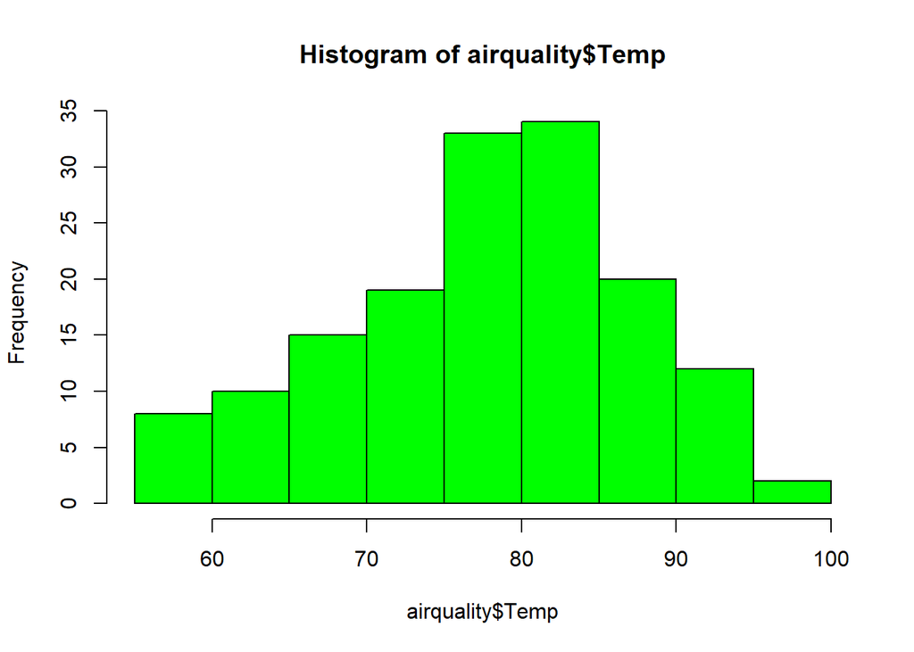

```r
# START YOUR CODE FROM HERE
hist(airquality$Temp, col = 'green')
```

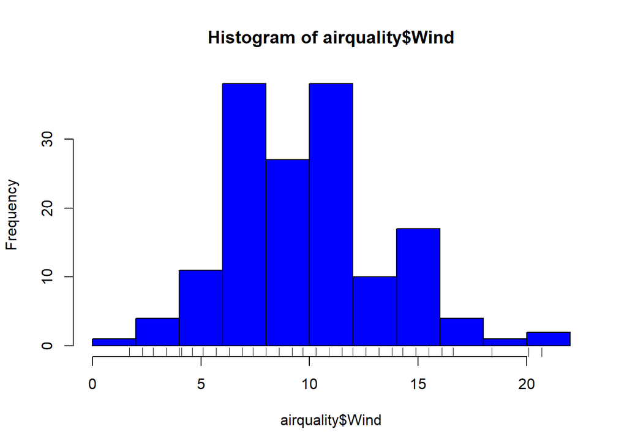

```r
hist(airquality$Wind, col = "blue")
rug(airquality$Wind)
```

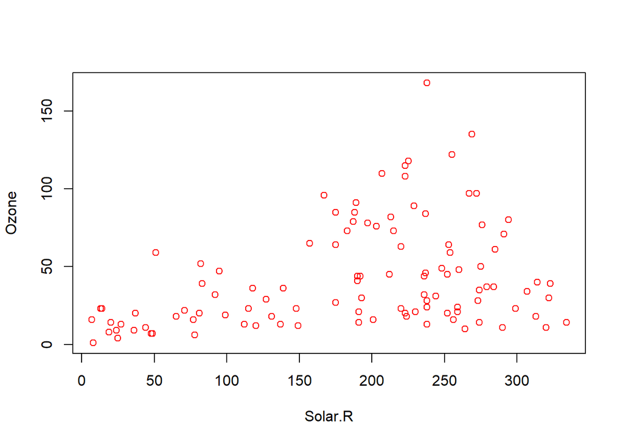

```r
with(airquality, plot(Solar.R, Ozone, col = 'red'))
```

### Good Job! You have completed this section!

## Section 2: Plotting Systems in R: Base, lattice, ggplot2

### Question 1

**The dataset is loaded for you. Perform the following tasks:**

1. Using the state.x77 and state.region datasets, visualize the relationship between Income and illiteracy.
2. Visualize the relationship between Population, region and life expectancy (Life.Exp)
3. Export the charts to a pdf file.

You can use either lattice or ggplot2 libraries to accomplish this task.

```r
library(lattice)
library(ggplot2)

head(state.x77)
```

```
##            Population Income Illiteracy Life Exp Murder HS Grad Frost   Area
## Alabama          3615   3624        2.1    69.05   15.1    41.3    20  50708
## Alaska            365   6315        1.5    69.31   11.3    66.7   152 566432
## Arizona          2212   4530        1.8    70.55    7.8    58.1    15 113417
## Arkansas         2110   3378        1.9    70.66   10.1    39.9    65  51945
## California      21198   5114        1.1    71.71   10.3    62.6    20 156361
## Colorado         2541   4884        0.7    72.06    6.8    63.9   166 103766
```

```r
head(state.region)
```

```
## [1] South West  West  South West  West
## Levels: Northeast South North Central West
```

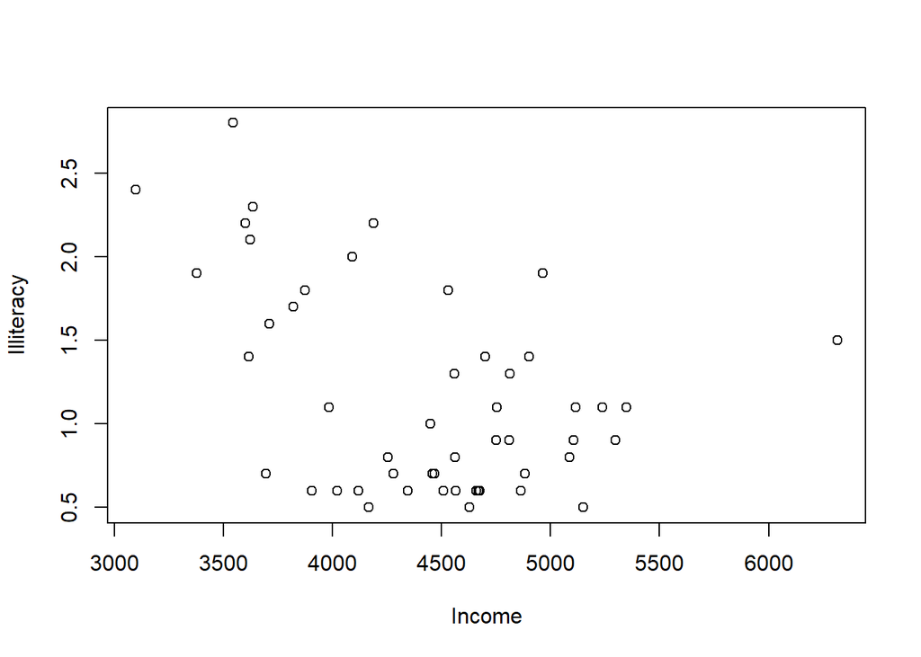

```r
# START YOUR CODE FROM HERE
state <- data.frame(state.x77, region= state.region)

with(state, plot(Income,Illiteracy))
```

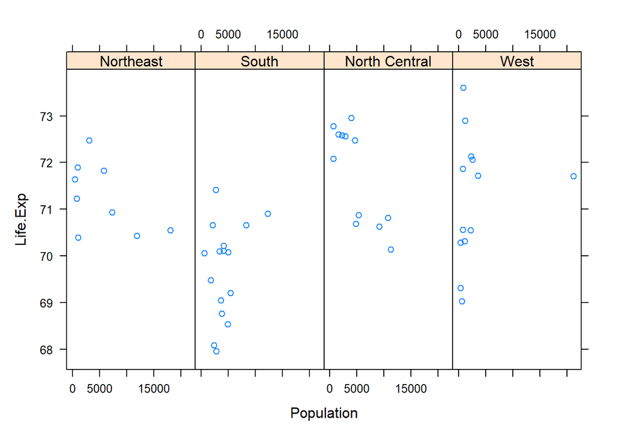

```r
xyplot(Life.Exp ~ Population | region, data = state, layout = c(4,1))
```

```r
pdf("rplot.pdf")
with(state, plot(Income,Illiteracy))

xyplot(Life.Exp ~ Population | region, data = state, layout = c(4,1))
dev.off()
```

### Question 2

**The dataset is loaded for you. Perform the following tasks:**

1. Using the visualize the relationship between height and weight from the women dataset.
2. Is there a strong correlation between the two quantities? Compute correlation coefficient and fit a linear regression model
3. Export the charts and results to a pdf file.

```r
head(women)
```

```
##   height weight
## 1     58    115
## 2     59    117
## 3     60    120
## 4     61    123
## 5     62    126
## 6     63    129
```

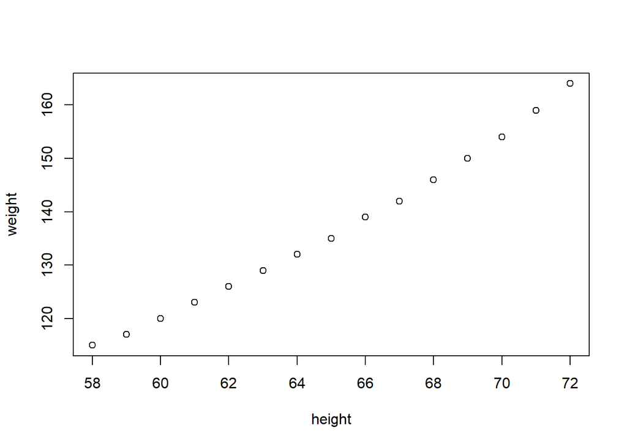

```r
# START YOUR CODE FROM HERE
with(women, plot(height, weight))
```

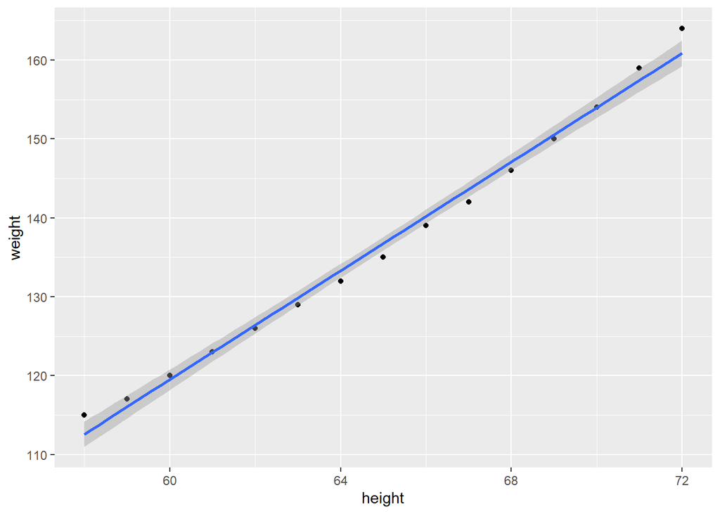

```r
g <- ggplot(women, aes(height, weight))
g + geom_point() + geom_smooth(method = 'lm')
```

### Good Job! You have completed this section!

## Section 3: Aesthetics and Visuals of ggplot2

### Question 1

**The dataset is loaded for you. Perform the following tasks:**

1. Using the longley dataset, plot the relationship between Umployed and GNP.
2. As a scatter plot, plot out Unemployed values as blue dots and Employed values as green dots.
3. Create a new variable as a column known as Armed.Forces.Unemployed.Rel. In it, place a Y for when the number of armed forces are greater than unemployed and N otherwise. Plot a graph to show the relationship between unemployed and armed forces and use the Armed.Forces.Unemployed.Rel for aesthetics and color.

Add appropriate title, axis labels and charts for EACH of the above charts. You need to use ggplot2 to accomplish this task.

```r
head(longley)
```

```
##      GNP.deflator     GNP Unemployed Armed.Forces Population Year Employed
## 1947         83.0 234.289      235.6        159.0    107.608 1947   60.323
## 1948         88.5 259.426      232.5        145.6    108.632 1948   61.122
## 1949         88.2 258.054      368.2        161.6    109.773 1949   60.171
## 1950         89.5 284.599      335.1        165.0    110.929 1950   61.187
## 1951         96.2 328.975      209.9        309.9    112.075 1951   63.221
## 1952         98.1 346.999      193.2        359.4    113.270 1952   63.639
```

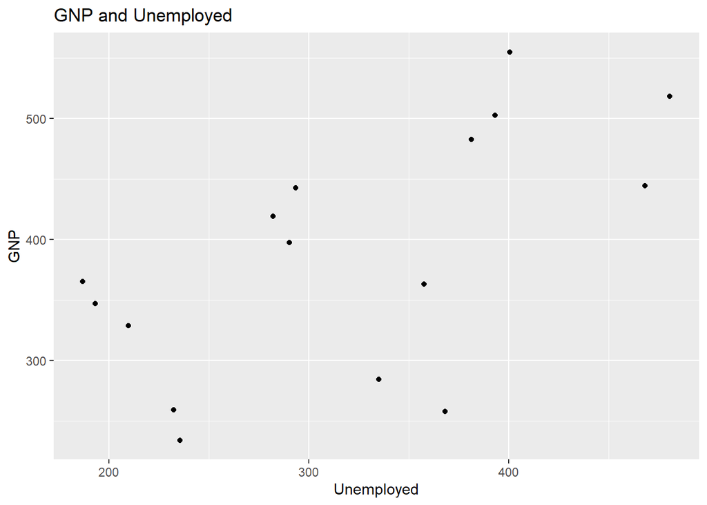

```r
# START YOUR CODE FOR GRAPH-1
g <- ggplot(data = longley, aes(Unemployed, GNP))
g + geom_point() + labs(title = "GNP and Unemployed")
```

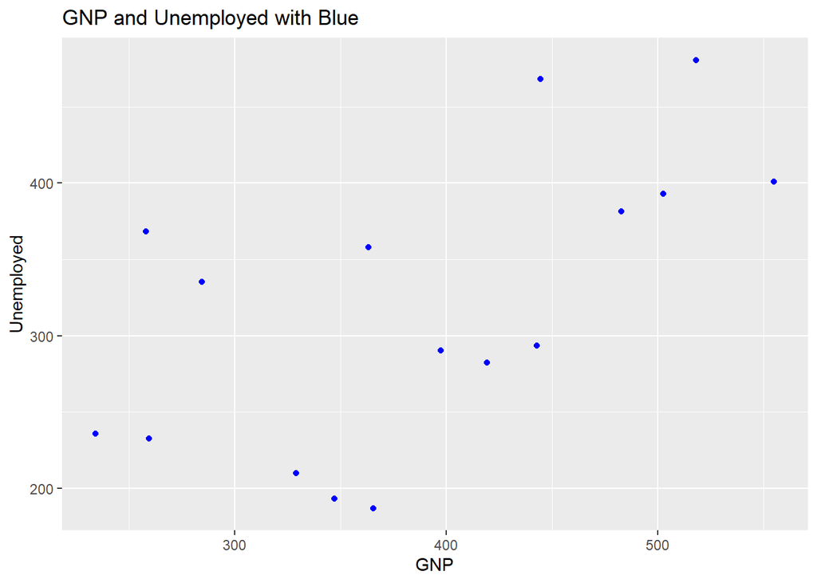

```r
# START YOUR CODE fFOR GRAPH-2
ggplot(longley, aes(GNP, Unemployed))+ geom_point(color = "blue")+labs(title = "GNP and Unemployed with Blue")
```

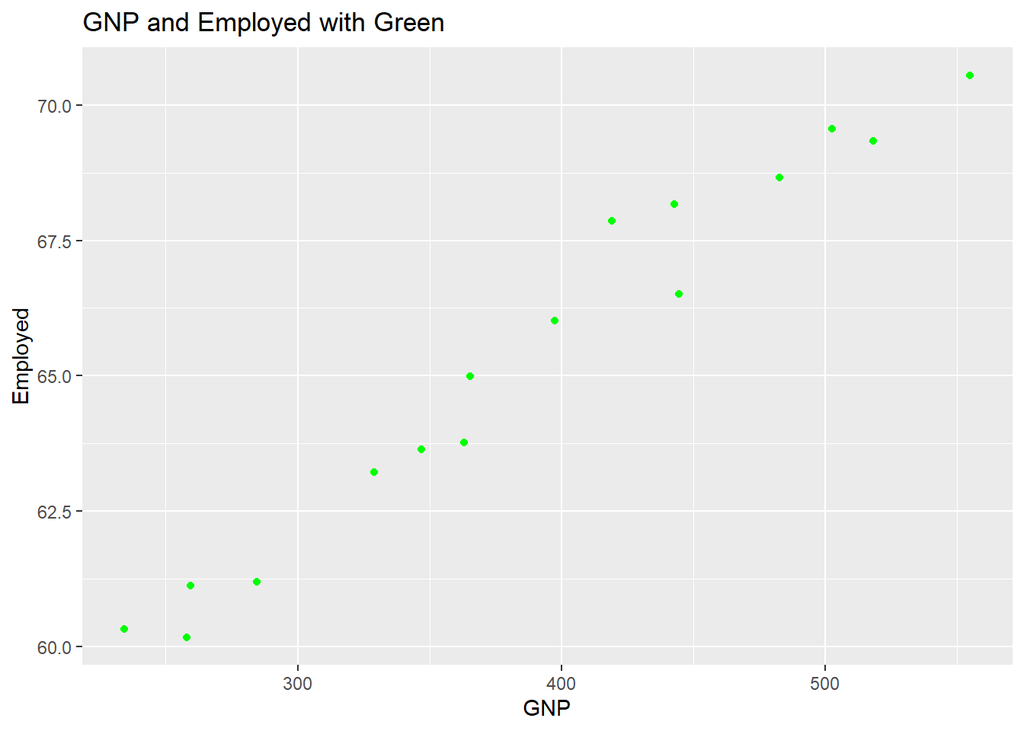

```r
ggplot(longley, aes(GNP, Employed))+ geom_point(color = "Green")+labs(title = "GNP and Employed with Green")
```

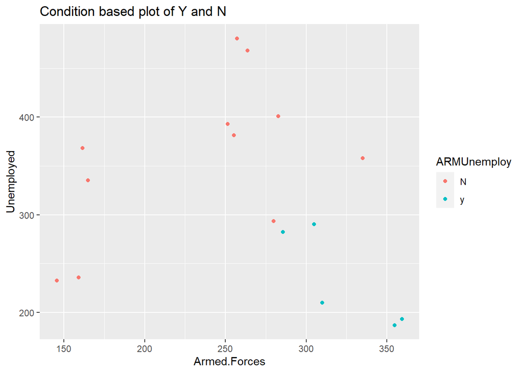

```r
# START YOUR CODE FOR GRAPH-3

Armed.Forces.Unemployed.Rel <- ifelse(longley$Armed.Forces > longley$Unemployed, "y", "N")

longley$ARMUnemploy <- Armed.Forces.Unemployed.Rel

ggplot(longley, aes(Armed.Forces, Unemployed, colour = ARMUnemploy))+ geom_point()+labs(title = "Condition based plot of Y and N")
```

### Congratulations! You have successfully completed this course and practice exercises!